# Topic 3.5: Neural Networks and MLPs

Binary classification, multiclass classification, and regression in R

Advanced Modelling, Master in Computational Social Science

UC3M, 2025-2026

# 1 Introduction

In this notebook we practice the basic workflow for fitting a simpel MLPs network in R, using `caret` and `nnet` packages.

> Have a look at the `nnet` function documentation: [Link](https://www.rdocumentation.org/packages/nnet/versions/7.3-20/topics/nnet)

There are many other options to train NNs in R, such as the `tensorflow` package (which requires installing Python in the background) or the `torch` package, but these are out of the scope of this course.

We will solve 3 example toy problems:

1. binary classification on `iris` modified to be 2 classes
2. multiclass classification on full `iris`
3. regression on Sacramento house prices

```r
library(tidyverse)
library(caret)
library(nnet)

theme_set(theme_minimal())
```

# 2 Binary Classification on `iris`

We start with the lightest possible example: turn `iris` into a binary problem by asking whether a flower is `setosa` or not.

To keep the geometry intuitive, we only use `Petal.Length` and `Petal.Width` in this first example.

```r
data(iris)

iris_binary <- iris %>%
  transmute(
    Petal.Length,
    Petal.Width,
    Class = factor(
      if_else(Species == "setosa", "setosa", "other"),
      levels = c("setosa", "other")
    )
  )

set.seed(3501)
iris_binary_idx <- createDataPartition(iris_binary$Class, p = 0.7, list = FALSE)
iris_binary_train <- iris_binary[iris_binary_idx, ]
iris_binary_test  <- iris_binary[-iris_binary_idx, ]

cat("Train:", nrow(iris_binary_train), "| Test:", nrow(iris_binary_test), "\n")
```

```
## Train: 105 | Test: 45
```

Before fitting the model, it helps to visualize the two classes:

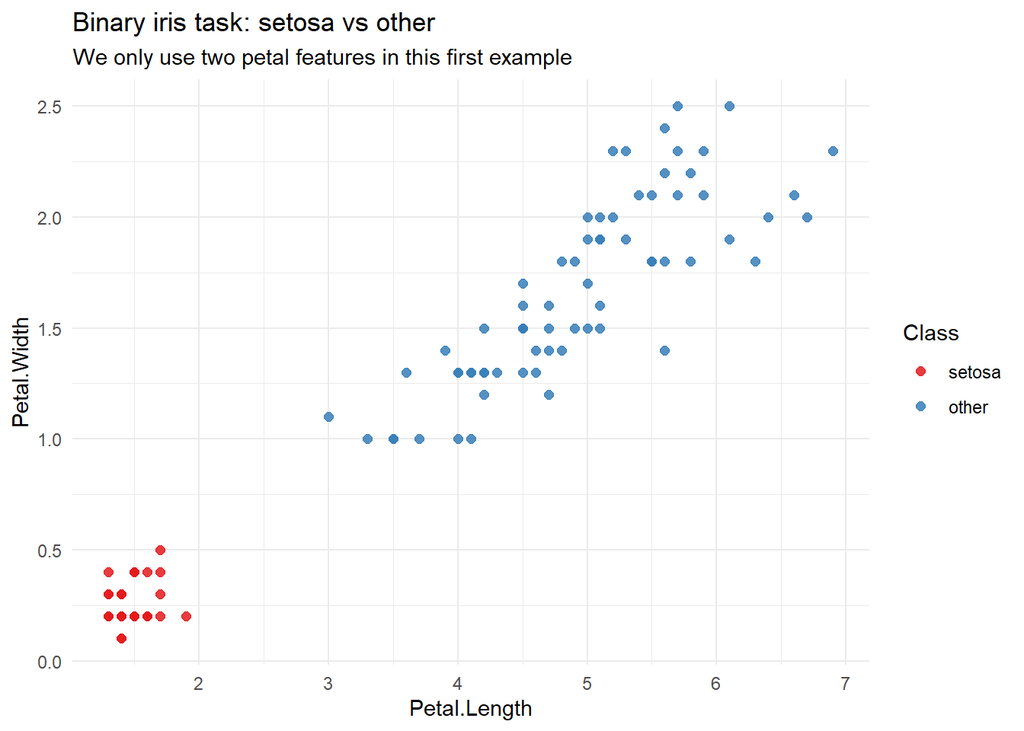

```r
ggplot(iris_binary_train, aes(x = Petal.Length, y = Petal.Width, color = Class)) +
  geom_point(size = 2, alpha = 0.85) +
  labs(
    title = "Binary iris task: setosa vs other",
    subtitle = "We only use two petal features in this first example"
  ) +
  scale_color_brewer(palette = "Set1")
```

For this first model we use a small tuning grid:

- `size`: number of hidden units,
- `decay`: weight decay, a simple regularization parameter.

`caret` handles the tuning and control

```r
ctrl_class <- trainControl(
  method = "repeatedcv",
  number = 5,
  repeats = 1,
  classProbs = TRUE,
  savePredictions = "final"
)

set.seed(3502)
iris_binary_fit <- train(
  Class ~ .,
  data = iris_binary_train,
  method = "nnet",
  metric = "Accuracy",
  preProcess = c("center", "scale"),
  trControl = ctrl_class,
  tuneGrid = expand.grid(
    size = c(1, 3, 5),
    decay = c(0, 0.01, 0.1)
  ),
  trace = TRUE,
  maxit = 300
)
iris_binary_fit
```

```
## Neural Network
##
## 105 samples
##   2 predictor
##   2 classes: 'setosa', 'other'
##
## Pre-processing: centered (2), scaled (2)
## Resampling: Cross-Validated (5 fold, repeated 1 times)
## Summary of sample sizes: 84, 84, 84, 84, 84
## Resampling results across tuning parameters:
##
##   size  decay  Accuracy  Kappa
##   1     0.00   1         1
##   1     0.01   1         1
##   1     0.10   1         1
##   3     0.00   1         1
##   3     0.01   1         1
##   3     0.10   1         1
##   5     0.00   1         1
##   5     0.01   1         1
##   5     0.10   1         1
##
## Accuracy was used to select the optimal model using the largest value.
## The final values used for the model were size = 1 and decay = 0.1.
```

For binary classification, one very useful output is the predicted probability of the positive class.

```r
iris_binary_prob <- predict(iris_binary_fit, newdata = iris_binary_test, type = "prob")
head(iris_binary_prob)
```

```
##       setosa      other
## 2  0.9569806 0.04301943
## 3  0.9579499 0.04205011
## 8  0.9558606 0.04413936
## 10 0.9580608 0.04193916
## 14 0.9607707 0.03922929
## 15 0.9587903 0.04120969
```

We can now turn those probabilities into hard class labels using a threshold of `0.5`.

```r
iris_binary_pred <- factor(
  if_else(iris_binary_prob$setosa >= 0.5, "setosa", "other"),
  levels = levels(iris_binary_test$Class)
)

confusionMatrix(iris_binary_pred, iris_binary_test$Class)
```

```
## Confusion Matrix and Statistics
##
##           Reference
## Prediction setosa other
##     setosa     15     0
##     other       0    30
##
##                Accuracy : 1
##                  95% CI : (0.9213, 1)
##     No Information Rate : 0.6667
##     P-Value [Acc > NIR] : 1.191e-08
##
##                   Kappa : 1
##
##  Mcnemar's Test P-Value : NA
##
##             Sensitivity : 1.0000
##             Specificity : 1.0000
##          Pos Pred Value : 1.0000
##          Neg Pred Value : 1.0000
##              Prevalence : 0.3333
##          Detection Rate : 0.3333
##    Detection Prevalence : 0.3333
##       Balanced Accuracy : 1.0000
##
##        'Positive' Class : setosa
##
```

Because we only used two predictors, we can visualize the smooth decision surface learned by the MLP.

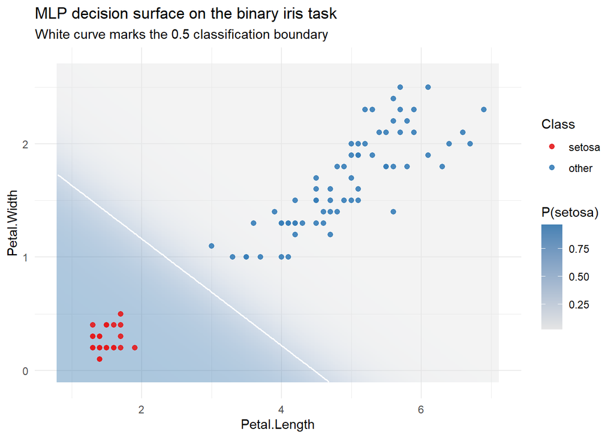

```r
iris_binary_grid <- expand.grid(
  Petal.Length = seq(
    min(iris_binary$Petal.Length) - 0.2,
    max(iris_binary$Petal.Length) + 0.2,
    length.out = 200
  ),
  Petal.Width = seq(
    min(iris_binary$Petal.Width) - 0.2,
    max(iris_binary$Petal.Width) + 0.2,
    length.out = 200
  )
)

iris_binary_grid$prob_setosa <- predict(
  iris_binary_fit,
  newdata = iris_binary_grid,
  type = "prob"
)[, "setosa"]

ggplot() +
  geom_tile(
    data = iris_binary_grid,
    aes(x = Petal.Length, y = Petal.Width, fill = prob_setosa),
    alpha = 0.45
  ) +
  geom_contour(
    data = iris_binary_grid,
    aes(x = Petal.Length, y = Petal.Width, z = prob_setosa),
    breaks = 0.5,
    color = "white",
    linewidth = 0.7
  ) +
  geom_point(
    data = iris_binary_train,
    aes(x = Petal.Length, y = Petal.Width, color = Class),
    size = 1.8,
    alpha = 0.9
  ) +
  scale_fill_gradient(low = "grey90", high = "steelblue") +
  scale_color_brewer(palette = "Set1") +
  labs(
    title = "MLP decision surface on the binary iris task",
    subtitle = "White curve marks the 0.5 classification boundary",
    fill = "P(setosa)"
  )
```

# 3 Multiclass Classification on Full `iris`

Now we keep the same workflow, but return to the original three-species classification problem.

The main conceptual change is that the output layer now produces one score per class instead of one probability for a yes/no outcome.

```r
iris_multi <- iris

set.seed(3503)
iris_multi_idx <- createDataPartition(iris_multi$Species, p = 0.7, list = FALSE)
iris_multi_train <- iris_multi[iris_multi_idx, ]
iris_multi_test  <- iris_multi[-iris_multi_idx, ]

cat("Train:", nrow(iris_multi_train), "| Test:", nrow(iris_multi_test), "\n")
```

```
## Train: 105 | Test: 45
```

```r
ctrl_multi <- trainControl(
  method = "repeatedcv",
  number = 5,
  repeats = 1,
  classProbs = TRUE,
  savePredictions = "final"
)

set.seed(3504)
iris_multi_fit <- train(
  Species ~ .,
  data = iris_multi_train,
  method = "nnet",
  metric = "Accuracy",
  preProcess = c("center", "scale"),
  trControl = ctrl_multi,
  tuneGrid = expand.grid(
    size = c(2, 4, 6),
    decay = c(0, 0.01, 0.1)
  ),
  trace = TRUE,
  maxit = 300
)
iris_multi_fit
```

```
## Neural Network
##
## 105 samples
##   4 predictor
##   3 classes: 'setosa', 'versicolor', 'virginica'
##
## Pre-processing: centered (4), scaled (4)
## Resampling: Cross-Validated (5 fold, repeated 1 times)
## Summary of sample sizes: 84, 84, 84, 84, 84
## Resampling results across tuning parameters:
##
##   size  decay  Accuracy   Kappa
##   2     0.00   0.9333333  0.9000000
##   2     0.01   0.9523810  0.9285714
##   2     0.10   0.9523810  0.9285714
##   4     0.00   0.9523810  0.9285714
##   4     0.01   0.9619048  0.9428571
##   4     0.10   0.9523810  0.9285714
##   6     0.00   0.9238095  0.8857143
##   6     0.01   0.9333333  0.9000000
##   6     0.10   0.9523810  0.9285714
##
## Accuracy was used to select the optimal model using the largest value.
## The final values used for the model were size = 4 and decay = 0.01.
```

```r
head(predict(iris_multi_fit, newdata = iris_multi_test, type = "prob"))
```

```
##       setosa  versicolor    virginica
## 2  0.9960174 0.003965115 1.745972e-05
## 5  0.9970537 0.002931107 1.515936e-05
## 6  0.9969106 0.003073943 1.550339e-05
## 12 0.9968326 0.003151698 1.568355e-05
## 14 0.9969267 0.003057797 1.546286e-05
## 17 0.9970661 0.002918752 1.513212e-05
```

```r
iris_multi_pred <- predict(iris_multi_fit, newdata = iris_multi_test)
confusionMatrix(iris_multi_pred, iris_multi_test$Species)
```

```
## Confusion Matrix and Statistics
##
##             Reference
## Prediction   setosa versicolor virginica
##   setosa         15          0         0
##   versicolor      0         15         1
##   virginica       0          0        14
##
## Overall Statistics
##
##                Accuracy : 0.9778
##                  95% CI : (0.8823, 0.9994)
##     No Information Rate : 0.3333
##     P-Value [Acc > NIR] : < 2.2e-16
##
##                   Kappa : 0.9667
##
##  Mcnemar's Test P-Value : NA
##
## Statistics by Class:
##
##                      Class: setosa Class: versicolor Class: virginica
## Sensitivity                 1.0000            1.0000           0.9333
## Specificity                 1.0000            0.9667           1.0000
## Pos Pred Value              1.0000            0.9375           1.0000
## Neg Pred Value              1.0000            1.0000           0.9677
## Prevalence                  0.3333            0.3333           0.3333
## Detection Rate              0.3333            0.3333           0.3111
## Detection Prevalence        0.3333            0.3556           0.3111
## Balanced Accuracy           1.0000            0.9833           0.9667
```

As with the binary case, we can visualize the learned decision regions. Because this model uses 4 predictors, we draw the surface over `Petal.Length` and `Petal.Width`, while holding `Sepal.Length` and `Sepal.Width` fixed at their training medians.

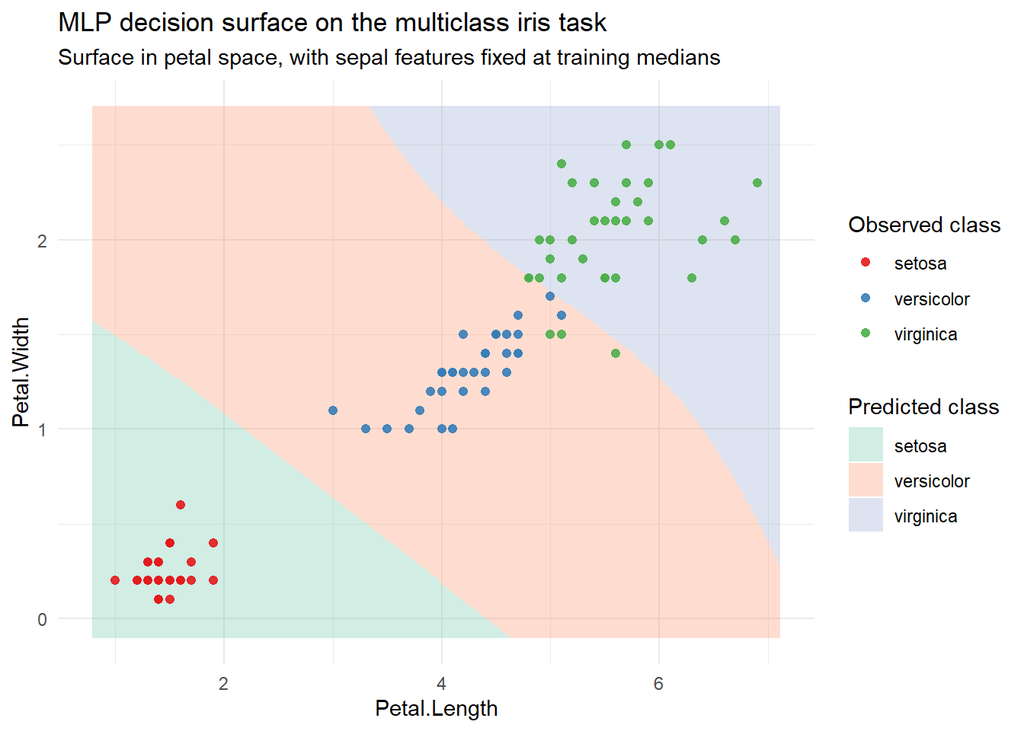

```r
iris_multi_grid <- expand.grid(
  Petal.Length = seq(
    min(iris_multi$Petal.Length) - 0.2,
    max(iris_multi$Petal.Length) + 0.2,
    length.out = 250
  ),
  Petal.Width = seq(
    min(iris_multi$Petal.Width) - 0.2,
    max(iris_multi$Petal.Width) + 0.2,
    length.out = 250
  )
)

iris_multi_grid$Sepal.Length <- median(iris_multi_train$Sepal.Length)
iris_multi_grid$Sepal.Width  <- median(iris_multi_train$Sepal.Width)

iris_multi_grid$pred_species <- predict(iris_multi_fit, newdata = iris_multi_grid)

ggplot() +
  geom_tile(
    data = iris_multi_grid,
    aes(x = Petal.Length, y = Petal.Width, fill = pred_species),
    alpha = 0.30
  ) +
  geom_point(
    data = iris_multi_train,
    aes(x = Petal.Length, y = Petal.Width, color = Species),
    size = 1.8,
    alpha = 0.9
  ) +
  scale_fill_brewer(palette = "Set2") +
  scale_color_brewer(palette = "Set1") +
  labs(
    title = "MLP decision surface on the multiclass iris task",
    subtitle = "Surface in petal space, with sepal features fixed at training medians",
    fill = "Predicted class",
    color = "Observed class"
  )
```

# 4 Regression on Sacramento House Prices

We now switch to regression. This example reuses the Sacramento case study from Topic 3.4, but the focus here is only on fitting a neural network for prediction.

The feature engineering below is the same basic preprocessing logic used in Topic 3.4: log-transform skewed variables, remove problematic rows, and add a few simple engineered features. We do not repeat the full preprocessing motivation here.

```r
data(Sacramento)

prepare_sacramento_data <- function(df) {
  df %>%
    filter(price > 0, sqft > 0, baths > 0) %>%
    drop_na(price, beds, baths, sqft, type, city, zip, latitude, longitude) %>%
    mutate(
      bedsperbath = beds / baths,
      log_price   = log(price),
      log_sqft    = log(sqft),
      latitude2   = latitude^2,
      longitude2  = longitude^2
    ) %>%
    select(
      price,
      log_price,
      beds,
      baths,
      log_sqft,
      type,
      latitude,
      longitude,
      bedsperbath,
      latitude2,
      longitude2
    )
}

set.seed(3505)
sac_idx <- createDataPartition(Sacramento$price, p = 0.75, list = FALSE)
sac_train_raw <- Sacramento[sac_idx, ]
sac_test_raw  <- Sacramento[-sac_idx, ]

sac_train <- prepare_sacramento_data(sac_train_raw)
sac_test  <- prepare_sacramento_data(sac_test_raw)

cat("Train after cleaning:", nrow(sac_train), "| Test after cleaning:", nrow(sac_test), "\n")
```

```
## Train after cleaning: 700 | Test after cleaning: 232
```

And we build the desired predictor formula

```r
sac_formula <- log_price ~ beds + baths + log_sqft + type +
  latitude + longitude + bedsperbath + latitude2 + longitude2
```

For regression we keep the same `size` and `decay` tuning idea, but tell `nnet` to use a linear output with `linout = TRUE`.

```r
ctrl_reg <- trainControl(
  method = "repeatedcv",
  number = 5,
  repeats = 1
)

set.seed(3506)
sac_nn_fit <- train(
  sac_formula,
  data = sac_train,
  method = "nnet",
  metric = "RMSE",
  preProcess = c("center", "scale"),
  trControl = ctrl_reg,
  tuneGrid = expand.grid(
    size = c(3, 5, 7),
    decay = c(0, 0.01, 0.1)
  ),
  trace = TRUE,
  linout = TRUE,
  maxit = 500,
  MaxNWts = 2000
)
sac_nn_fit
```

```
## Neural Network
##
## 700 samples
##   9 predictor
##
## Pre-processing: centered (10), scaled (10)
## Resampling: Cross-Validated (5 fold, repeated 1 times)
## Summary of sample sizes: 561, 560, 560, 559, 560
## Resampling results across tuning parameters:
##
##   size  decay  RMSE       Rsquared   MAE
##   3     0.00   0.4546855  0.4864826  0.2623701
##   3     0.01   0.3570752  0.5664270  0.2529103
##   3     0.10   0.3341459  0.5973456  0.2505013
##   5     0.00   0.3756597  0.5329452  0.2757955
##   5     0.01   0.3401168  0.5924020  0.2567202
##   5     0.10   0.3381567  0.5915211  0.2505270
##   7     0.00   0.3586547  0.5599360  0.2654298
##   7     0.01   0.3629013  0.5512180  0.2672669
##   7     0.10   0.3259704  0.6179096  0.2460526
##
## RMSE was used to select the optimal model using the smallest value.
## The final values used for the model were size = 7 and decay = 0.1.
```

```r
sac_nn_pred_log <- predict(sac_nn_fit, newdata = sac_test)

metrics_table <-
  as_tibble_row(postResample(pred = sac_nn_pred_log, obs = sac_test$log_price)) %>%
    mutate(Model = "Neural network", .before = 1)

metrics_table
```

```
## # A tibble: 1 × 4
##   Model           RMSE Rsquared   MAE
##   <chr>          <dbl>    <dbl> <dbl>
## 1 Neural network 0.334    0.605 0.248
```

The model is trained on `log_price`, but for interpretation we plot predictions back on the original dollar scale.

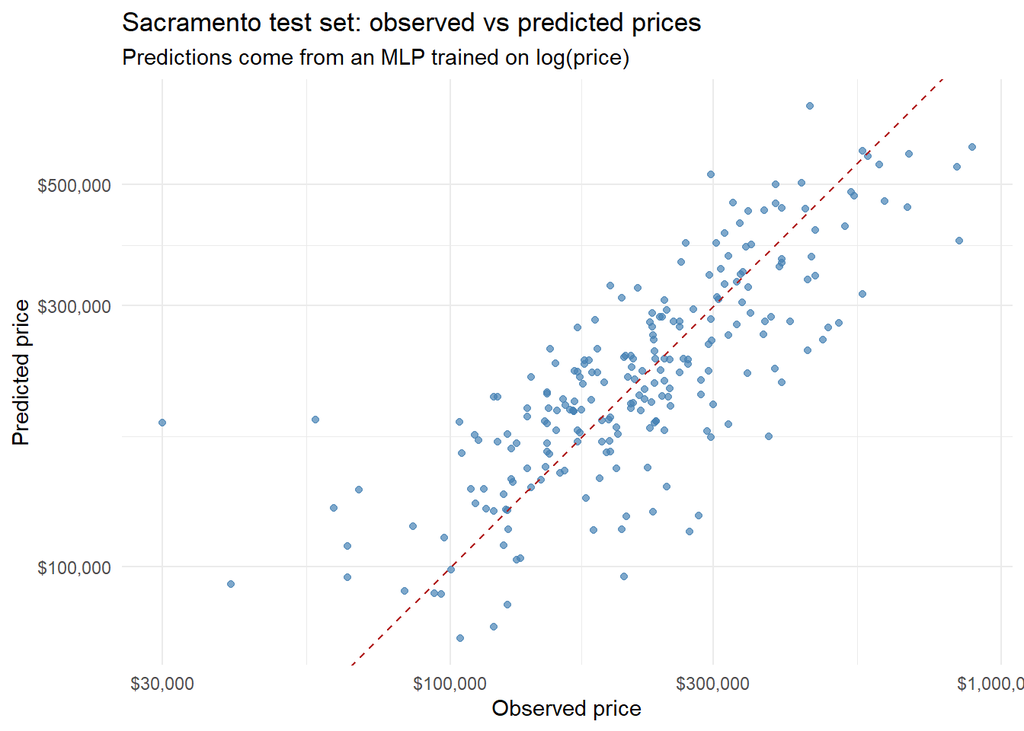

```r
sac_results <- tibble(
  observed_log = sac_test$log_price,
  predicted_log = sac_nn_pred_log,
  observed_price = exp(observed_log),
  predicted_price = exp(predicted_log)
)

ggplot(sac_results, aes(x = observed_price, y = predicted_price)) +
  geom_point(alpha = 0.7, color = "steelblue") +
  geom_abline(intercept = 0, slope = 1, linetype = "dashed", color = "firebrick") +
  scale_x_log10(labels = scales::dollar_format()) +
  scale_y_log10(labels = scales::dollar_format()) +
  labs(
    title = "Sacramento test set: observed vs predicted prices",
    subtitle = "Predictions come from an MLP trained on log(price)",
    x = "Observed price",
    y = "Predicted price"
  )
```

# 5 Final Remarks

We have seen a very short and simple way of fitting small NNs with packages that do not allow tuning all the internal possibilities that a neural network has. If any one is in that, there are several tutorials on the [torch for R webpage](https://torch.mlverse.org/)